# Bank Marketing Conversion

```r
knitr::opts_chunk$set(warning = FALSE, message = FALSE)
library(tidyverse)
library(plotly)
library(pROC)
library(broom)
library(caret)
# library(randomForest)
library(ranger)
```

## Overview

We are working with a dataset from a Portuguese bank. The data categorizes direct marketing efforts (phone calls) designed to sell term deposit products. The [dataset](https://archive.ics.uci.edu/ml/datasets/Bank+Marketing) was donated to UCI’s Machine Learning Repository.

The goal of this analysis is to use the data to tailor future marketing efforts. The “client” has a known cost per interaction, and would like to deploy those costs in scenarios that maximize the return on their investment.

### General Approach

We explore two modeling methods that can be used to estimate the exepcted value of customer contacts in future marketing campaigns. First, we apply a logistic regression that gives an easily interpertable model for scoring the likliehood that a customer subscribes; this can produce a continuous “expected customer value.”

Second, we build a random forest model that provides a more “black box” scoring model. Additionally, this model provides discrete categorizations rather than probabalistic estimates. This means that each cohort has a shared “expected value.”

These approaches are far from exhaustive. They show, however, that analytic techniques can help banks to deploy scarce resources to higher-than-average value marketing targets.

### Deliverables

- Project Overview Document
- Shiny Application for stratifying and scoring future cohorts
  - Market to all
  - Market to some - Logistic Regression with different cutoffs
  - Market to some - Multi-level Random Forest Model
- Tutorial Discussing Technical Implementation of Logistic Regression and Random Forest Model

## Analysis

### Load Data

```r
# raw_data <- read_delim("data/bank-additional/bank-additional-full.csv", ";")
#
# names(raw_data) <- stringr::str_replace_all(names(raw_data), "[.]", "_")
raw_data <- readRDS("all_data.RDS")
```

[output not shown]

### Exploratory Data Analysis

```r
eda <- all_data %>%
  mutate(total = n()) %>%
  group_by(term_deposit) %>%
  summarize(count = n(),
            percentage = n()/head(total, 1))
eda
```

| term_deposit | count | percentage |
| --- | --- | --- |
| no | 36548 | 0.8873458 |
| yes | 4640 | 0.1126542 |

- Over time (Macro variable, month)
- % of Cell Phone
- Age binned

### Training Data For Analysis

```r
set.seed(3456)
trainIndex <- createDataPartition(all_data$term_deposit, p = .5,
                                  list = FALSE,
                                  times = 1)
training_and_test_data <- all_data %>%
  mutate(
    education = case_when(
      education %in% c("basic.4y", "basic.6y", "illiterate") ~ "less.than.5.years",
      TRUE ~ education
    ),
    train_or_test = case_when(
      row_number() %in% trainIndex ~ "train",
      TRUE ~ "test"
    )
  ) %>%
  select(-nearZeroVar(.)) %>%
  select(-in_default) %>%
  mutate_at(
    vars(job, marital, education, housing_loan, personal_loan, contact, month, day_of_week, prior_outcome, term_deposit),
    funs(as_factor(.))) %>%
  mutate(term_deposit = fct_relevel(term_deposit, "yes", "no")) %>%
  group_by(train_or_test) %>%
  nest()
training_data <- training_and_test_data %>%
  filter(train_or_test == "train") %>%
  unnest() %>%
  select(-train_or_test)
testing_data <- training_and_test_data %>%
  filter(train_or_test == "test") %>%
  unnest() %>%
  select(-train_or_test)
```

### Logistic Regression

In this context, a negative co-efficient makes it more likely that someone will purchase a term_deposit (i.e. a positive number is “no purchase”).

```r
m1 <- glm(term_deposit ~ ., binomial, training_data)
summary(m1)
```

```
Call:
glm(formula = term_deposit ~ ., family = binomial, data = training_data)

Deviance Residuals:
    Min       1Q   Median       3Q      Max
-3.0103   0.2434   0.3336   0.4049   2.1984

Coefficients: (1 not defined because of singularities)
                               Estimate Std. Error z value Pr(>|z|)
(Intercept)                  -1.570e+02  7.032e+02  -0.223 0.823296
age                           2.020e-04  2.980e-03   0.068 0.945966
jobservices                  -1.692e-01  2.131e-01  -0.794 0.427084
jobadmin                     -3.726e-01  1.991e-01  -1.871 0.061284 .
jobbluecollar                -2.282e-01  2.004e-01  -1.139 0.254770
jobtechnician                -3.327e-01  2.047e-01  -1.625 0.104071
jobretired                   -6.172e-01  2.160e-01  -2.858 0.004265 **
jobmanagement                -2.998e-01  2.149e-01  -1.395 0.162981
jobunemployed                -2.361e-01  2.427e-01  -0.973 0.330655
jobselfemployed              -2.763e-01  2.357e-01  -1.172 0.241181
jobunknown                   -6.370e-02  3.449e-01  -0.185 0.853476
jobentrepreneur              -4.568e-01  2.357e-01  -1.938 0.052580 .
jobstudent                   -7.566e-01  2.333e-01  -3.243 0.001181 **
maritalsingle                -6.024e-02  6.329e-02  -0.952 0.341260
maritaldivorced               9.511e-02  8.665e-02   1.098 0.272367
maritalunknown                3.696e-02  6.557e-01   0.056 0.955055
educationhigh.school         -5.878e-03  9.882e-02  -0.059 0.952570
educationbasic.9y             9.477e-02  1.020e-01   0.929 0.352855
educationprofessional.course  3.045e-03  1.125e-01   0.027 0.978403
educationunknown             -1.420e-01  1.375e-01  -1.033 0.301675
educationuniversity.degree   -1.784e-03  1.000e-01  -0.018 0.985767
housing_loanyes               1.447e-02  5.095e-02   0.284 0.776438
housing_loanunknown          -2.040e-01  1.568e-01  -1.301 0.193161
personal_loanyes             -3.066e-03  7.004e-02  -0.044 0.965082
personal_loanunknown                 NA         NA      NA       NA
contactcellular              -5.080e-01  9.307e-02  -5.458 4.81e-08 ***
monthjun                     -6.917e-01  1.102e-01  -6.275 3.50e-10 ***
monthjul                     -8.926e-01  9.993e-02  -8.932  < 2e-16 ***
monthaug                     -6.414e-01  1.279e-01  -5.013 5.35e-07 ***
monthoct                     -8.224e-01  1.489e-01  -5.523 3.34e-08 ***
monthnov                     -6.246e-01  1.061e-01  -5.888 3.90e-09 ***
```

[output cut: 10 more lines]

```
cons_price_idx               -5.461e-01  2.181e-01  -2.503 0.012298 *
cons_conf_idx                -4.947e-02  6.894e-03  -7.176 7.20e-13 ***
euribor3m                     6.151e-01  1.604e-01   3.834 0.000126 ***
total_contacts                3.946e-02  1.241e-02   3.180 0.001472 **
year                          1.034e-01  3.596e-01   0.288 0.773701
---
Signif. codes:  0 ‘***’ 0.001 ‘**’ 0.01 ‘*’ 0.05 ‘.’ 0.1 ‘ ’ 1

(Dispersion parameter for binomial family taken to be 1)

    Null deviance: 14499  on 20593  degrees of freedom
Residual deviance: 11472  on 20549  degrees of freedom
AIC: 11562

Number of Fisher Scoring iterations: 6
```

Examine all statistically significant indicators (p.value < .05) in descending order of the absolute value of the coefficient.

```r
tidy(m1) %>%
  filter(p.value < .05) %>%
  arrange(desc(abs(estimate)))
```

| term | estimate | std.error | statistic | p.value |
| --- | --- | --- | --- | --- |
| monthmar | -1.51157239 | 0.182127238 | -8.299541 | 1.045148e-16 |
| prior_outcomesuccess | -1.36584825 | 0.098395783 | -13.881167 | 8.239204e-44 |
| monthdec | -1.25585155 | 0.267206167 | -4.699935 | 2.602446e-06 |
| monthjul | -0.89259949 | 0.099934469 | -8.931848 | 4.189508e-19 |
| monthoct | -0.82244014 | 0.148923308 | -5.522575 | 3.340672e-08 |
| jobstudent | -0.75655207 | 0.233260575 | -3.243377 | 1.181216e-03 |
| monthjun | -0.69168727 | 0.110232140 | -6.274824 | 3.500301e-10 |
| monthaug | -0.64139783 | 0.127940679 | -5.013244 | 5.351998e-07 |
| monthapr | -0.62895237 | 0.092418186 | -6.805504 | 1.006958e-11 |
| monthnov | -0.62457975 | 0.106071037 | -5.888316 | 3.901513e-09 |

[output cut: 12 more lines]

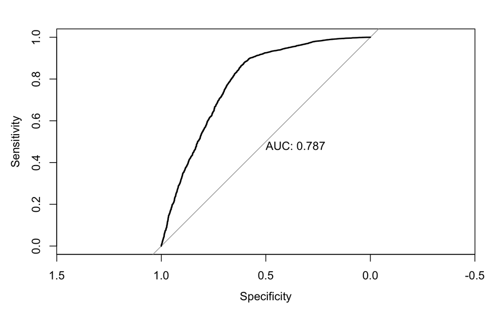

```r
# Predict
pred <- bind_rows("train" = training_data, "test" = testing_data, .id = "data") %>%
  mutate(
    pred = predict(m1, ., type = "response")) %>%
  mutate(decile = ntile(desc(pred), 10)) %>%
  select(data, term_deposit, pred, decile)
# ROC plot
pred %>%
  filter(data == "test") %>%
  roc(term_deposit ~ pred, .) %>%
  plot.roc(., print.auc = TRUE)
```

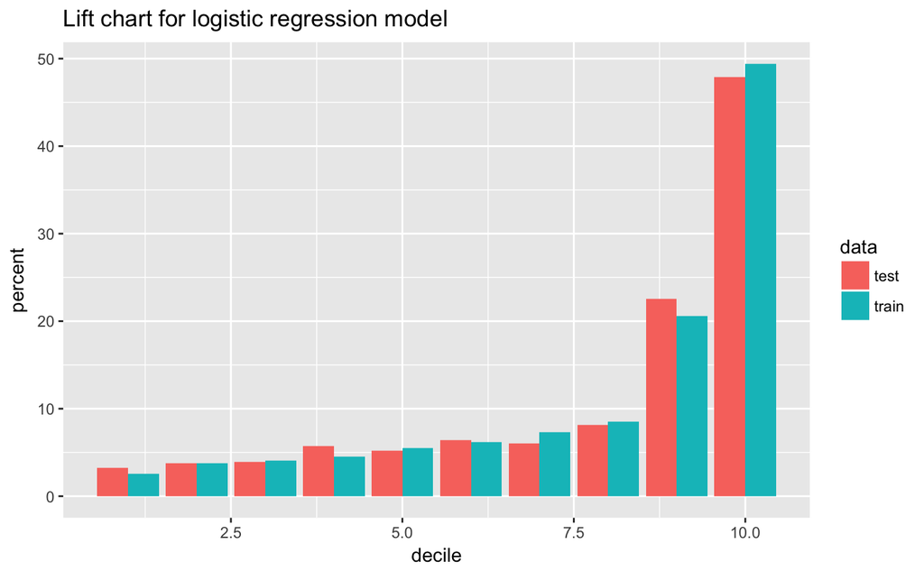

```r
# Lift plot
pred %>%
  group_by(data, decile) %>%
  summarize(percent = 100 * (mean(ifelse(term_deposit == "no", 0, 1)))) %>%
  ggplot(aes(decile, percent, fill = data)) + geom_bar(stat = "Identity", position = "dodge") +
  ggtitle("Lift chart for logistic regression model")
```

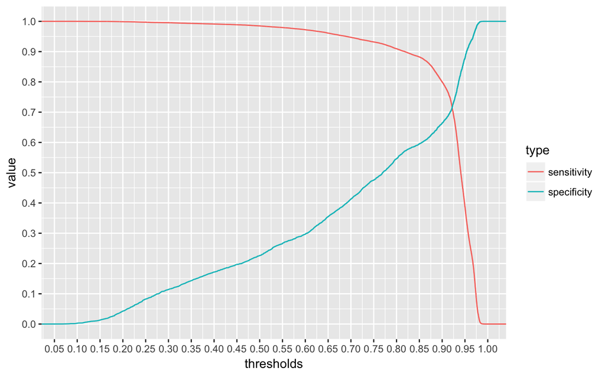

```r
# Sensitivity Vs Specificity
roc_output <- roc(term_deposit ~ pred, pred)
sensitivity <- data_frame(value = roc_output$sensitivities, type = "sensitivity", thresholds = roc_output$thresholds)
specificity <- data_frame(value = roc_output$specificities, type = "specificity", thresholds = roc_output$thresholds)
# roc <- data_frame(value = roc_output$sensitivities/roc_output$specificities, type = "roc", thresholds = roc_output$thresholds)
data_to_plot <- bind_rows(sensitivity, specificity)
ggplot(data = data_to_plot, mapping = aes(color = type, x = thresholds, y = value)) + geom_line() + scale_x_continuous(name = "thresholds", breaks = seq(0, 1, .05)) + scale_y_continuous(name = "value", breaks = seq(0, 1, .1))
```

```r
# Picke a cutoff where the specificity is similar to the specificity of the random forest model, so that you compare sensitivities with similar TNRs.
cutoff <- .88
sample_test_logistic <- testing_data %>%
  mutate(
    predicted = case_when(
      predict(m1, ., type = 'response') <= cutoff ~ "yes",
      TRUE ~ "no")
  )

confusion_matrix_logistic <- confusionMatrix(sample_test_logistic$predicted, sample_test_logistic$term_deposit)
confusion_matrix_logistic
```

```
Confusion Matrix and Statistics

          Reference
Prediction   yes    no
       yes  1458  2789
       no    862 15485

               Accuracy : 0.8227
                 95% CI : (0.8174, 0.8279)
    No Information Rate : 0.8873
    P-Value [Acc > NIR] : 1

                  Kappa : 0.3492
 Mcnemar's Test P-Value : <2e-16

            Sensitivity : 0.6284
            Specificity : 0.8474
         Pos Pred Value : 0.3433
         Neg Pred Value : 0.9473
             Prevalence : 0.1127
         Detection Rate : 0.0708
   Detection Prevalence : 0.2062
      Balanced Accuracy : 0.7379

       'Positive' Class : yes
```

```r
prop.table(confusion_matrix_logistic$table)
```

```
          Reference
Prediction        yes         no
       yes 0.07079732 0.13542779
       no  0.04185685 0.75191803
```

### Random Forest Methodology Overview

```r
training_data_to_use <- training_data
# %>%
#   sample_n(1000)
ranger_model <- ranger(term_deposit ~  . , data = training_data_to_use )
trainctrl <- trainControl(verboseIter = TRUE, method="cv", number=3, savePredictions = TRUE, sampling = "down",
                          classProbs = TRUE)
caret_cv <- train(term_deposit ~ ., method = 'ranger', data = training_data_to_use, trControl = trainctrl, metric = 'Kappa', tuneLength = 5, importance = 'impurity')
```

```r
saveRDS(ranger_model, "ranger_model.RDS")
saveRDS(caret_cv, "caret_cv.RDS")
# ranger_model <- readRDS("ranger_model.RDS")
# caret_cv <- readRDS("caret_cv.RDS")
```

### Ranger Prediction

```r
sample_test_ranger <- testing_data %>%
  mutate(
    predicted = predictions(predict(ranger_model, .))
  )

confusion_matrix_ranger <- confusionMatrix(sample_test_ranger$predicted, sample_test_ranger$term_deposit)
confusion_matrix_ranger
```

```
Confusion Matrix and Statistics

          Reference
Prediction   yes    no
       yes   607   411
       no   1713 17863

               Accuracy : 0.8969
                 95% CI : (0.8926, 0.901)
    No Information Rate : 0.8873
    P-Value [Acc > NIR] : 6.48e-06

                  Kappa : 0.3167
 Mcnemar's Test P-Value : < 2.2e-16

            Sensitivity : 0.26164
            Specificity : 0.97751
         Pos Pred Value : 0.59627
         Neg Pred Value : 0.91249
             Prevalence : 0.11265
         Detection Rate : 0.02947
   Detection Prevalence : 0.04943
      Balanced Accuracy : 0.61957

       'Positive' Class : yes
```

```r
prop.table(confusion_matrix_ranger$table)
```

```
          Reference
Prediction        yes         no
       yes 0.02947460 0.01995727
       no  0.08317957 0.86738856
```

### Downsampled Prediction

```r
sample_caret_cv <- testing_data %>%
  mutate(
    predicted = predict(caret_cv, .)
  )

confusion_matrix_ranger <- confusionMatrix(sample_caret_cv$predicted, sample_caret_cv$term_deposit)
confusion_matrix_ranger
```

```
Confusion Matrix and Statistics

          Reference
Prediction   yes    no
       yes  1510  2940
       no    810 15334

               Accuracy : 0.8179
                 95% CI : (0.8126, 0.8232)
    No Information Rate : 0.8873
    P-Value [Acc > NIR] : 1

                  Kappa : 0.3498
 Mcnemar's Test P-Value : <2e-16

            Sensitivity : 0.65086
            Specificity : 0.83912
         Pos Pred Value : 0.33933
         Neg Pred Value : 0.94983
             Prevalence : 0.11265
         Detection Rate : 0.07332
   Detection Prevalence : 0.21608
      Balanced Accuracy : 0.74499

       'Positive' Class : yes
```

```r
prop.table(sample_caret_cv$table)
```

```
numeric(0)
```

```r
varImp(caret_cv)
```

```
ranger variable importance

  only 20 most important variables shown (out of 45)

                     Overall
euribor3m            100.000
year                  71.310
cons_conf_idx         49.773
cons_price_idx        42.218
prior_outcomesuccess  37.257
age                   29.959
contactcellular       23.672
total_contacts        13.745
monthoct               9.645
jobbluecollar          7.188
monthmar               6.993
jobretired             6.597
monthapr               6.420
maritalsingle          5.873
jobstudent             5.355
monthsep               5.178
prior_outcomefailure   4.201
educationbasic.9y      3.964
monthjun               3.644
monthaug               3.389
```

### Observations / Insights

#### Differences Between Un-Tuned and Tuned Models

#### Optimizing on Kappa Redux

### All Model Outcomes

```r
pred_all <- bind_rows("train" = training_data, "test" = testing_data, .id = "data") %>%
  mutate(
    logistic_predict_no = predict(m1, ., type = "response"),
    ranger_predict = predictions(predict(ranger_model, .)),
    downsample_predict = predict(caret_cv, .)
  )
saveRDS(pred_all, "predictions.RDS")
```

```r
summary_pred_all <- pred_all %>%
  mutate(
    number_of_rf_models = case_when(
      ranger_predict == "yes" & downsample_predict == "yes" ~ 2,
      ranger_predict == "yes" | downsample_predict == "yes" ~ 1,
      TRUE ~ 0
    ),
    optimized_cutoff_logistic = ifelse(logistic_predict_no <= cutoff, "yes", "no")
  ) %>%
  group_by(downsample_predict, optimized_cutoff_logistic, data) %>%
  summarize(
    median_logistic_prediction = round(median(logistic_predict_no), 2),
    average_logistic_prediction = round(mean(logistic_predict_no), 2),
    number_yes = sum(ifelse(term_deposit == "yes", 1, 0)),
    number_no = sum((ifelse(term_deposit == "no", 1, 0))),
    actual_yes_percentage = round(number_yes/n(), 2),
    total = n()
  ) %>%
  ungroup() %>%
  arrange(data, desc(downsample_predict))
  # arrange(data, desc(ninety_cutoff_logistic))
summary_pred_all
```

| downsample_predict | optimized_cutoff_logistic | data | median_logistic_prediction | average_logistic_prediction | number_yes | number_no | actual_yes_percentage | total |
| --- | --- | --- | --- | --- | --- | --- | --- | --- |
| no | no | test | 0.95 | 0.95 | 782 | 14984 | 0.05 | 15766 |
| no | yes | test | 0.86 | 0.85 | 28 | 350 | 0.07 | 378 |
| yes | no | test | 0.90 | 0.91 | 80 | 501 | 0.14 | 581 |
| yes | yes | test | 0.70 | 0.65 | 1430 | 2439 | 0.37 | 3869 |
| no | no | train | 0.95 | 0.95 | 742 | 15003 | 0.05 | 15745 |
| no | yes | train | 0.87 | 0.86 | 9 | 384 | 0.02 | 393 |
| yes | no | train | 0.90 | 0.91 | 113 | 398 | 0.22 | 511 |
| yes | yes | train | 0.71 | 0.65 | 1456 | 2489 | 0.37 | 3945 |

How do I add the expected value per category?